# Analysing the first whole proteome of MCF10A under insulin starved and unstarved conditions

Tom’s python script re-annotates all peptides to their master proteins and only keeps those that have a unique swissprot ID. Line 390 contains what is a “NonUnique” call by proteome discoverer due to multiple matchs - J3KN67 (TPM3_unreviewed); Q5TCU3(TPM2_unreviewed); Q6ZN40 (TPM1_unreviewed); P67936 (TPM4_Reviewed,Max annotation score); H0YK48(TPM1_unreviewed); A0A087WWU8 (TPM3_unreviewed); H7BYY1(TPM1_unreviewed); K7ENT6 (TPM4_unreviewed). However, Tom’s script calls it Unique with assignment ‘sp|P67936|TPM4_HUMAN’ which is the only reviewed protein so it is worth including these….

```r
# ---------------------------------------------------------------------------------
# Step 01 : Filter
# We perform 3 layers of filtering - unique proteins, contaminants,missing values
# Will re-annotate protein list with Tom's code for unique peptides
# ---------------------------------------------------------------------------------
# How many unique/non-unique proteins are there. Is there a difference in Proteome Discoverer and Tom's script annotations ?
peptide.stats = table(prot.data$Quan.Info,prot.data$unique)
peptide.stats
```

```
                   0     1
  NoQuanValues    77  4488
  NotUnique     1631  3098
  Unique           0 63575
```

```r
# Step 1a : Filter only for those peptides that have a unique master protein. Either
# 1. column "quan.info" has to be 'Unique' (or)
# 2. quan.info has to be "NonUnique" and "unique"" column == 1 and protein_description is not blank.
filt.1a = prot.data[which(prot.data$Quan.Info == "Unique" | (prot.data$Quan.Info == "NotUnique" & prot.data$unique == 1 & prot.data$protein_description != "")),]
dim(filt.1a) #63575 are unique peptides, 2633 are non-unique
```

```
[1] 66208    22
```

```r
# Step 1b : Filter out those proteins that are contaminants from the contaminants list but include those that are not contaminants based on Tom's calls.
# Tom's script adds 14 unique proteins (158 peptides) back into the study
filt.1b = filt.1a[-which(filt.1a$Master.Protein.Accessions %in% contam$Protein.Group.Accessions & (filt.1a$crap_protein == 1)),]
num.contams = length(which(filt.1a$Master.Protein.Accessions %in% contam$Protein.Group.Accessions & (filt.1a$crap_protein == 1)))
# Stats
dim(filt.1a) # 66208 in total
```

```
[1] 66208    22
```

```r
dim(filt.1b) # 65990 filtered peptides
```

```
[1] 65990    22
```

```r
print(num.contams) # 218 contaminant peptides
```

```
[1] 218
```

```r
# Adding extra information about rows with missing values
# 98% of rows are complete and have no missing values (n=64373)
# There are
filt.1b$count.missing = rowSums(is.na(filt.1b[,c(7:15)]))
table(filt.1b$count.missing)
```

```
    0     1     2     3     4     5     6     7     8
64373   442   254   200   140   126   146   139   170
```

```r
# Indicating which columns are missing information
filt.1b$Missing = FALSE
filt.1b$Missing[which(filt.1b$count.missing > 0)] = TRUE
head(filt.1b)
```

|  | Checked | Confidence | Sequence | Modifications | Qvality.PEP | Master.Protein.Accessions | A1_starved_2 | A2_starved_1 | A3_starved_3 | B1_Ins.30min_1 | B2_Ins.30min_3 | B3_Ins.30min_2 | C1_Ins.2hr_2 | C2_Ins.2hr_3 | C3_Ins.2hr_1 | Quan.Info | master_protein | protein_length | protein_description | crap_protein | unique | uniprot | count.missing | Missing |
| --- | --- | --- | --- | --- | --- | --- | --- | --- | --- | --- | --- | --- | --- | --- | --- | --- | --- | --- | --- | --- | --- | --- | --- | --- |
| 1 | False | High | VCGLATFEIDLKEAQR | 2xTMT6plex [N-Term; K12]; 1xCarbamidomethyl [C2] | 1.06678e-06 | O43583 | 134.6 | 120.9 | 130.7 | 104.5 | 124.0 | 126.1 | 145.4 | 132.6 | 119.2 | Unique | O43583 | 198 | sp\|O43583\|DENR_HUMAN | 0 | 1 | DENR_HUMAN | 0 | FALSE |
| 2 | False | High | LCTSATESEVAR | 1xTMT6plex [N-Term]; 1xCarbamidomethyl [C2] | 1.54547e-05 | P31930 | 57.8 | 56.3 | 54.3 | 50.7 | 48.9 | 47.5 | 68.7 | 50.0 | 49.3 | Unique | P31930 | 480 | sp\|P31930\|QCR1_HUMAN | 0 | 1 | QCR1_HUMAN | 0 | FALSE |
| 3 | False | High | MEELHNQEVQK | 2xTMT6plex [N-Term; K11] | 1.87870e-05 | Q15233 | 355.8 | 343.1 | 343.6 | 315.4 | 341.9 | 336.8 | 402.1 | 353.4 | 319.2 | Unique | Q15233 | 471 | sp\|Q15233\|NONO_HUMAN | 0 | 1 | NONO_HUMAN | 0 | FALSE |
| 4 | False | High | INMNGVNSSNGVVDPR | 1xTMT6plex [N-Term] | 2.73101e-06 | I3L0A0 | 10.6 | 10.1 | 8.1 | 6.7 | 9.6 | 9.3 | 12.1 | 11.2 | 9.9 | Unique |  |  |  | NA | 1 |  | 0 | FALSE |
| 5 | False | High | STDSSSYPSPCASPSPPSSGK | 2xTMT6plex [N-Term; K21]; 1xCarbamidomethyl [C11] | 3.47421e-06 | Q9H6S0 | 13.4 | 18.8 | 13.9 | 13.8 | 15.3 | 13.4 | 12.7 | 15.2 | 11.7 | Unique | Q9H6S0 | 1430 | sp\|Q9H6S0\|YTDC2_HUMAN | 0 | 1 | YTDC2_HUMAN | 0 | FALSE |
| 6 | False | High | QHGAVQSGGLNPELNDK | 2xTMT6plex [N-Term; K17] | 1.46860e-05 | Q9UHF7 | 7.3 | 12.2 | 9.5 | 11.4 | 9.0 | 10.2 | 10.2 | 12.3 | 13.2 | Unique | Q9UHF7 | 1281 | sp\|Q9UHF7\|TRPS1_HUMAN | 0 | 1 | TRPS1_HUMAN | 0 | FALSE |

```r
# Last step is to sort out those proteins that are meant to be unique but have multiple Master.Protein.Acessions
filt.1c = filt.1b
filt.1c$Master.Protein.Accessions[which(filt.1c$Quan.Info == "NotUnique")] = filt.1c$master_protein[which(filt.1c$Quan.Info == "NotUnique")]
```

We have a column called “Missing” to identify which peptides have one or more missing values across the 9 samples. “count.missing” tells us how many missing values there are for that peptide. 0 1 2 3 4 5 6 7 8 64373 442 254 200 140 126 146 139 170

```r
# ---------------------------------------------------------------------------------
# Step 02a : Creating an MSnSet which is needed for using the MSnbase backage
# ---------------------------------------------------------------------------------
# The rownames of samp.dat have to be the same as column names in the expression data matrix
rownames(samp.dat) = paste(samp.dat$Sample,samp.dat$Short.cond,samp.dat$Rep,sep="_")
# Create an MSnSet object
res <- MSnSet(exprs = as.matrix(filt.1c[,c(7:15)]),fData=filt.1c[,c(6,17,22,19,1:5,18,20:21,23)],pData = samp.dat[,c(2,1,4,6)])
dim(res)
```

```
[1] 65990     9
```

```r
res <- res[rowSums(is.na(exprs(res)))!=9,] # exclude peptides without any quantification
print(res)
```

```
MSnSet (storageMode: lockedEnvironment)
assayData: 65990 features, 9 samples
  element names: exprs
protocolData: none
phenoData
  sampleNames: A1_starved_2 A2_starved_1 ... C3_Ins.2hr_1 (9 total)
  varLabels: TMT Sample Short.cond Rep
  varMetadata: labelDescription
featureData
  featureNames: 1 2 ... 72869 (65990 total)
  fvarLabels: Master.Protein.Accessions master_protein ... count.missing (13 total)
  fvarMetadata: labelDescription
experimentData: use 'experimentData(object)'
Annotation:
- - - Processing information - - -
Subset [65990,9][65990,9] Tue Feb 20 21:24:28 2018
 MSnbase version: 2.0.2
```

```r
# How many missing values per peptide
table(fData(res)$count.missing)
```

```
    0     1     2     3     4     5     6     7     8
64373   442   254   200   140   126   146   139   170
```

```r
colSums(is.na(exprs(res)))
```

```
  A1_starved_2   A2_starved_1   A3_starved_3 B1_Ins.30min_1 B2_Ins.30min_3 B3_Ins.30min_2
           652            836            656            740            626            666
  C1_Ins.2hr_2   C2_Ins.2hr_3   C3_Ins.2hr_1
           482            528            763
```

```r
table(rowSums(is.na(exprs(res))))
```

```
    0     1     2     3     4     5     6     7     8
64373   442   254   200   140   126   146   139   170
```

```r
# Checking missing values
table(is.na(res))
```

```
 FALSE   TRUE
587961   5949
```

The MSnSet object has been created to include protein abundance values, some metadata and sample information (Insulin treatment in this case)

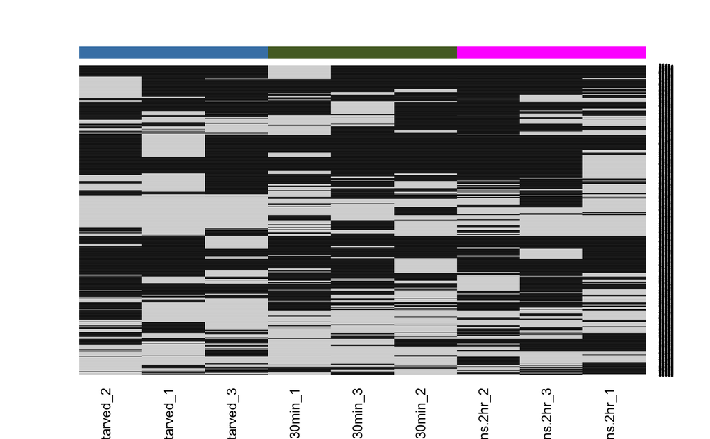

```r
# ---------------------------------------------------------------------------------
# Step 02b : Imputing missing values in the protein expression data using 'impute'
# ---------------------------------------------------------------------------------
# Subsetting only those peptides with one or more missing values
# Replacing missing values with 0 and non-missing with 1
# Displaying missing values
miss.many = res[rowSums(is.na(exprs(res)))>=1,] # There are 5949 missing values in the matrix of 590,000 entries so approx 1%. Very small
exprs(miss.many)[exprs(miss.many) != 0] = 1
exprs(miss.many)[is.na(exprs(miss.many))] = 0
heatmap.2(exprs(miss.many), col = c("lightgray", "black"),
            scale = "none", dendrogram = "none",
            trace = "none", keysize = 0.5, key = FALSE,Colv=F,
            ColSideColors = rep(c("steelblue", "darkolivegreen","magenta"), times = c(3,3,3)))
```

```r
# Impute missing values
# Imputes values based on nearest neighbours. This means that after the imputation, the mean and median of the data remain the same as before imputation
impute.res <- MSnbase::impute(res,method = "knn")
```

```
581 rows with more than 50 % entries missing;
 mean imputation used for these rows
```

[output not shown]

[output cut: 149 more lines]

[output not shown]

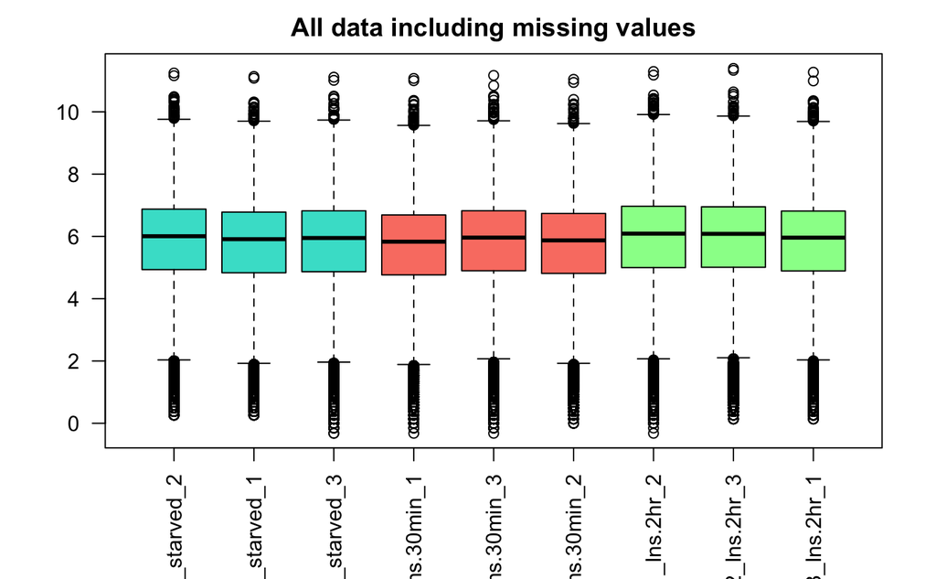

```r
# Plot imputed values
res.miss = melt(exprs(res))
colnames(res.miss) = c("Row","Dosage","Abundance_imp")
res.no.miss = melt(exprs(impute.res))
colnames(res.no.miss) = c("Row","Dosage","Abundance")
# Imputed values
imp.vals = res.no.miss[which(is.na(res.miss$Abundance_imp)),]
# Some boxplots of the data
#---------------------------
# All data including missing values
boxplot(log2(res.miss$Abundance)~as.factor(res.miss$Dosage),las=2,col=rep(c("turquoise", "salmon","palegreen"),times=c(3,3,3)),main="All data including missing values")
```

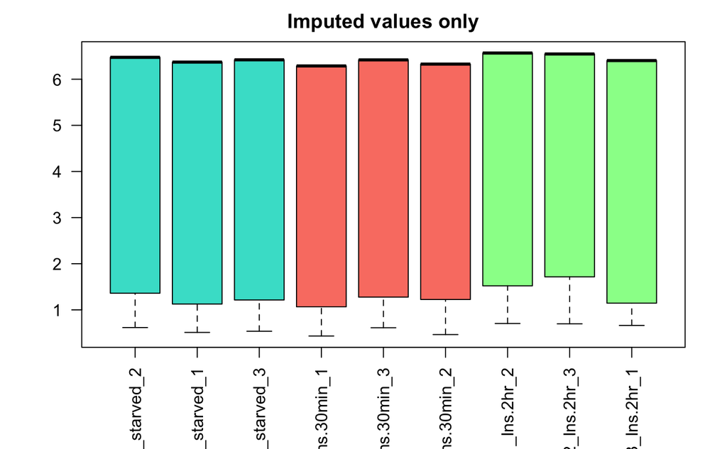

```r
# Imputed values/missing values only
b.imp = boxplot(log2(imp.vals$Abundance)~imp.vals$Dosage,las=2,col=rep(c("turquoise", "salmon","palegreen"),times=c(3,3,3)),main="Imputed values only")
```

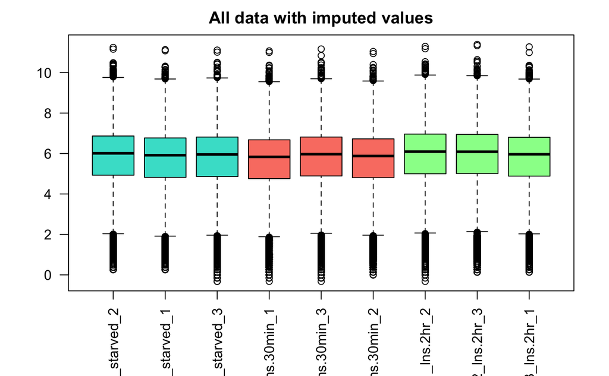

```r
# All data icluding newly imputed values
boxplot(log2(res.no.miss$Abundance)~as.factor(res.no.miss$Dosage),las=2,col=rep(c("turquoise", "salmon","palegreen"),times=c(3,3,3)),main="All data with imputed values")
```

```r
# ---------------------------------------------------------------------------------
# Step 03 : Normalising imputed data using various methods to determine ideal one
# ---------------------------------------------------------------------------------
## ---- plotting function---------
.plot <- function(x,ttl=NULL) {
  boxplot(exprs(x),
          main=ifelse(is.null(ttl),processingData(x)@processing[2],ttl),
          cex.main=1.5,
          cex.lab=.5,
          cex.axis=0.8,
          cex=.8,
          las=2)
  grid()
}
qnt.max <- normalise(impute.res, "max")
qnt.sum <- normalise(impute.res, "sum")
qnt.quant <- normalise(impute.res, "quantiles")
qnt.qrob <- normalise(impute.res, "quantiles.robust")
# Choosing vsn normalisation
qnt.vsn <- normalise(impute.res, "vsn")
```

```
vsn2: 65990 x 9 matrix (1 stratum). Please use 'meanSdPlot' to verify the fit.
```

```r
# Using the plotting function to plot boxplots for all diff types of normalisation methods
oldmar <- par()$mar
par(mfrow=c(3,2),mar=c(2.9,2.9,2.9,1))
.plot(impute.res, ttl = "Non-normalised data")
.plot(qnt.max, ttl = "Maximum")
```

```r
.plot(qnt.sum, ttl = "Sum")
.plot(qnt.quant, ttl = "Quantile")
```

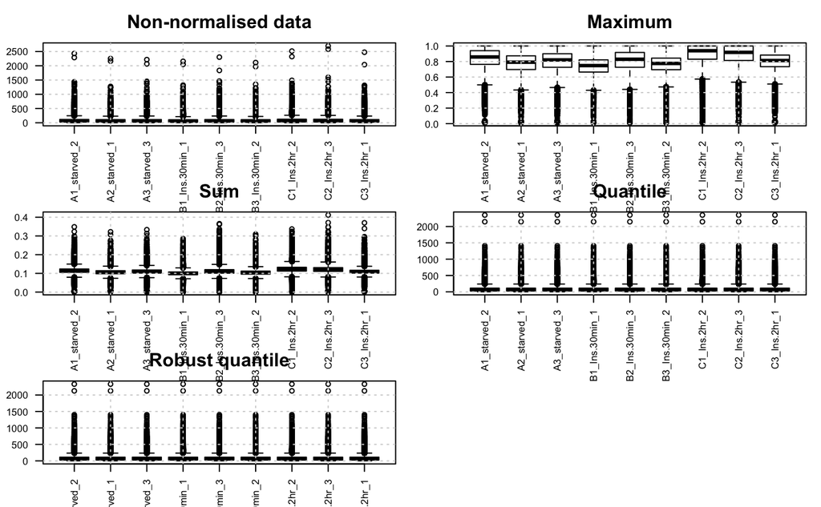

```r
.plot(qnt.qrob, ttl = "Robust quantile")
.plot(qnt.vsn, ttl = "vsn")
```

For all further steps, we will use the object “qnt.vsn”

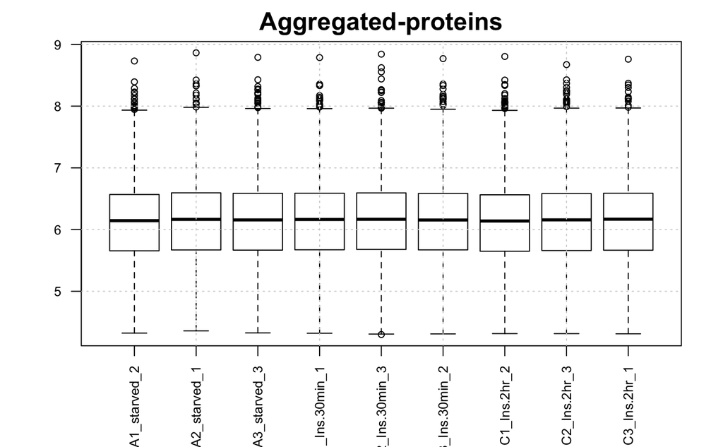

```r
# ---------------------------------------------------------------------------------
# Step 04a : Aggregate peptide data to protein expression values
# There is an in-built function called 'combineFeatures' to do thi within MSnBase
# ---------------------------------------------------------------------------------
# To peptide groups
#pep.imp <- fData(qnt.vsn)$Sequence
#qnt.pep.imp <- combineFeatures(qnt.vsn, groupBy = pep.imp, fun = "median") # 61798 features
#names(fData(qnt.pep.imp)) = gsub("CV\\.","",names(fData(qnt.pep.imp))) # CV needs to be removed a swith the next round of aggregation, another round of "CV" gets added
# To protein groups
#prot.imp <- fData(qnt.pep.imp)$Master.Protein.Accessions
#length(unique(prot.imp)) # 5919 proteins present in all 9 samples (some imputed values)
# Aggregating peptide abundance values into protein abundance values
#qnt.prot.imp <- combineFeatures(qnt.pep.imp, groupBy = prot.imp, fun = "median") # 65590 features
#qnt.prot.imp
#dim(qnt.prot.imp) # 5919
#saveRDS(qnt.prot.imp,file = "Input/Aggregated-whole-proteome-with-imputation.rds")
qnt.prot.imp = readRDS("Input/Aggregated-whole-proteome-with-imputation.rds")
pData(qnt.prot.imp) = pData(impute.res)
# Looking at how the data have been combined
#head(exprs(qnt.vsn))
#head(exprs(qnt.prot.imp))
# Basic plots of protein data across samples
.plot(qnt.prot.imp,ttl="Aggregated-proteins")
```

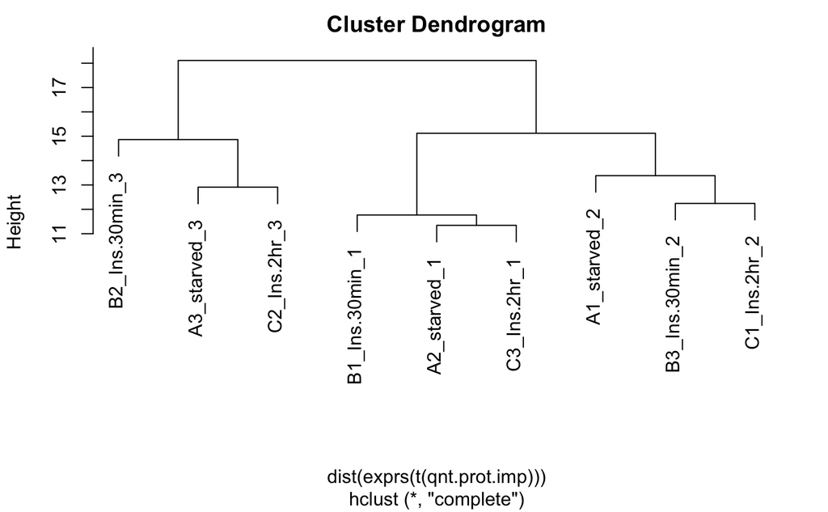

```r
plot(hclust(dist(exprs(t(qnt.prot.imp)))))
```

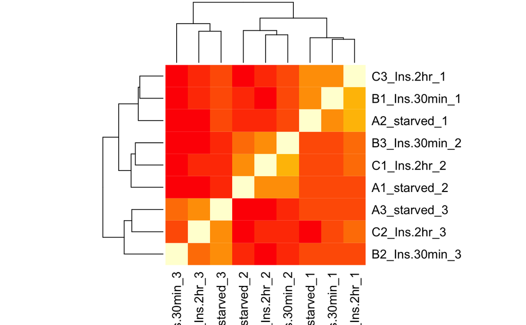

```r
# Looking at sample correlations
cor.prot.imp = cor(exprs(qnt.prot.imp))
heatmap(cor.prot.imp,cex.main = 0.8)
```

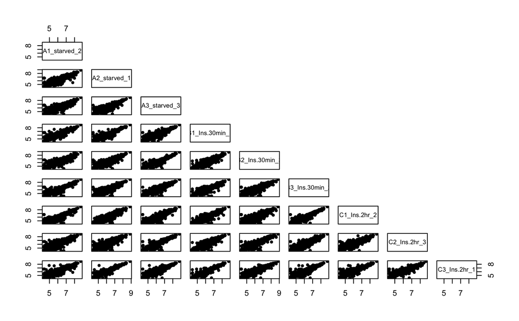

```r
pairs(x = exprs(qnt.prot.imp), upper.panel=NULL, pch=20)
```

It is very obvious based on the clustering and heatmaps that the samples are clustering based on the replicate number or the date on which the experiment was performed. This would be considered a batch effect and needs to be accounted for before downstream analyses.

```r
# ---------------------------------------------------------------------------------
# Step 04a : Plotting PCAs and correcting for batch effect using ComBat
# This is to look at variability across samples and within replicates
# ---------------------------------------------------------------------------------
# Across all 9 samples
prot.pca.imp = prcomp(t(exprs(qnt.prot.imp)),scale=T)
summary(prot.pca.imp)
```

```
Importance of components:
                           PC1     PC2     PC3     PC4      PC5      PC6      PC7      PC8       PC9
Standard deviation     36.9231 31.2792 28.9927 25.6640 23.98502 22.84542 22.55991 21.72414 2.904e-13
Proportion of Variance  0.2303  0.1653  0.1420  0.1113  0.09719  0.08818  0.08599  0.07973 0.000e+00
Cumulative Proportion   0.2303  0.3956  0.5376  0.6489  0.74611  0.83428  0.92027  1.00000 1.000e+00
```

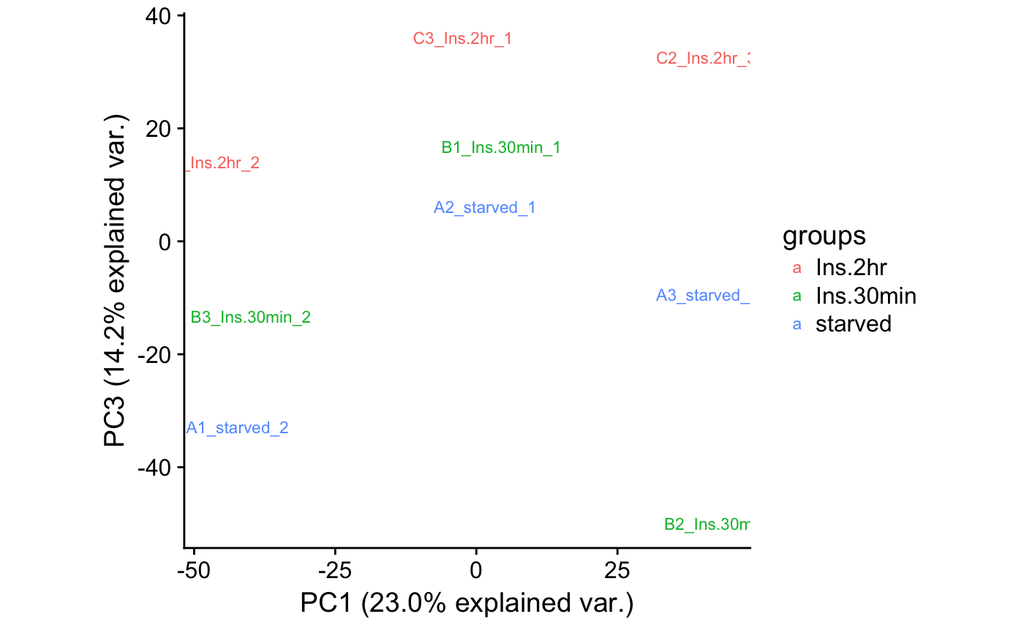

```r
# PCA plot of samples
# very obvious that samples are separating by date of experiment. Need to correct for this before progressing with analysis
j <- ggbiplot(prot.pca.imp,choices=c(1,3), var.axes=F, groups = factor(rep(c("starved","Ins.30min","Ins.2hr"),times=c(3,3,3))), circle = T,obs.scale=1,labels=rownames(prot.pca.imp$x))
print(j)
```

```
Found 3 batches
Adjusting for 0 covariate(s) or covariate level(s)
Standardizing Data across genes
Fitting L/S model and finding priors
Finding parametric adjustments
Adjusting the Data
```

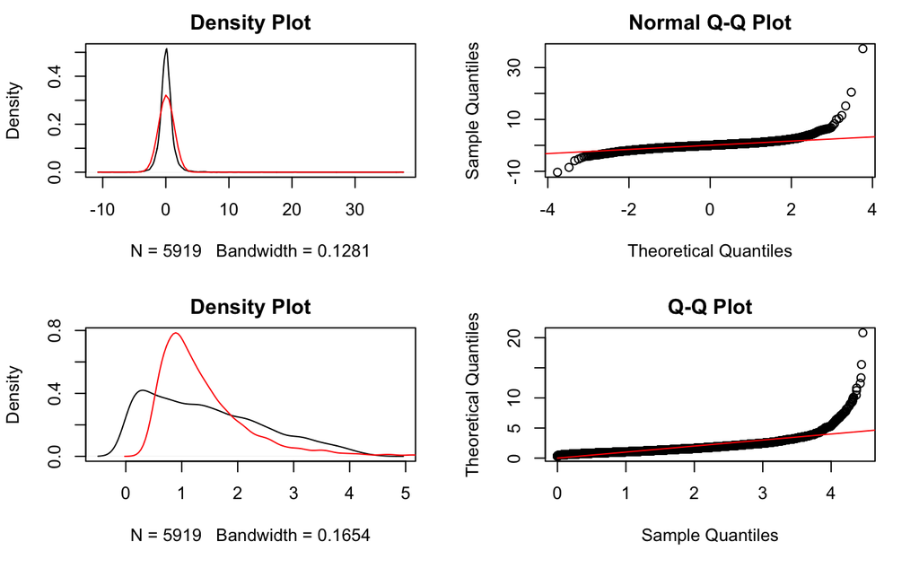

```r
# Trying to correct for batch effect
pheno.imp = pData(qnt.prot.imp)
edata.imp = exprs(qnt.prot.imp)
feat.imp = featureData(qnt.prot.imp)
# Combat model
batch.imp = pheno.imp$Rep
modcombat.imp = model.matrix(~1,data=pheno.imp)
# Batch corrected data. Since data are imputed, there are no missing values and ComBat works.....
combat_edata.imp = sva::ComBat(dat=edata.imp, batch=batch.imp, mod=modcombat.imp, par.prior=TRUE, prior.plots=T)
```

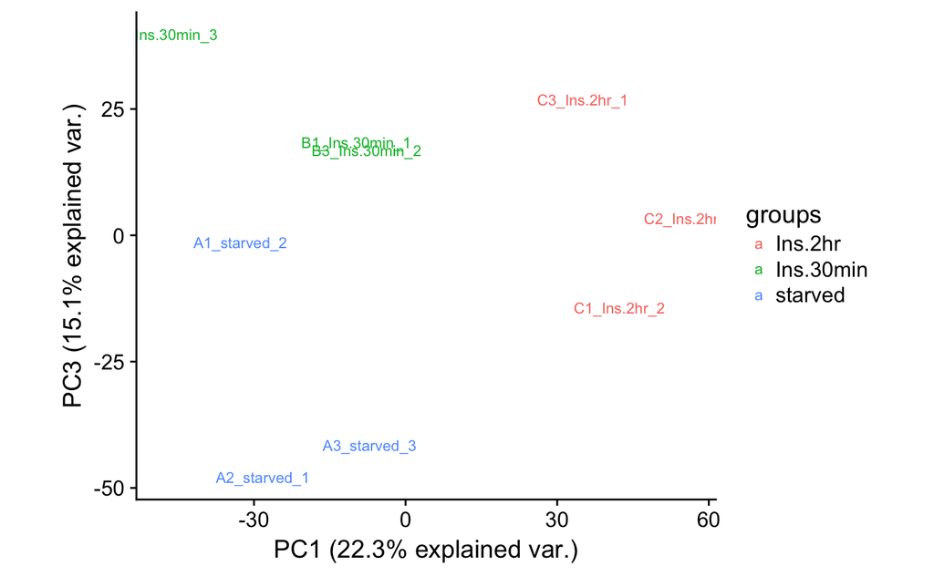

```r
combat.pca.imp = prcomp(t(combat_edata.imp),scale=T)
# PCA plot to check the impact of batch correction
y <- ggbiplot(combat.pca.imp, choices = c(1,3),var.axes=F, groups = factor(rep(c("starved","Ins.30min","Ins.2hr"),times=c(3,3,3))), circle = T,obs.scale=1,labels=rownames(combat.pca.imp$x))
print(y)
```

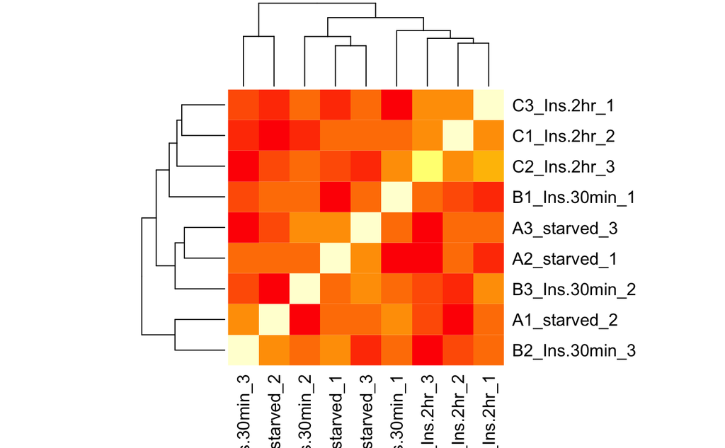

```r
# Assign batch corrected data to new MsnSet
combat.qnt.prot.imp = qnt.prot.imp
exprs(combat.qnt.prot.imp) = combat_edata.imp
# Some plots to check post-batch correction correlations
cor.combat.prot.imp = cor(exprs(combat.qnt.prot.imp))
heatmap(cor.combat.prot.imp,cex.main = 0.8)
```

[figure not shown]

```r
plot(hclust(dist(exprs(t(combat.qnt.prot.imp)))))
```

```r
# Write max expression for each gene to file
mcf10a.bias = data.frame(cbind(uniprot =rownames(exprs(combat.qnt.prot.imp)),max=round(rowMax(exprs(combat.qnt.prot.imp)),2)))
b = bitr(geneID = mcf10a.bias$uniprot,fromType = "UNIPROT",toType = "SYMBOL",OrgDb = org.Hs.eg.db,drop=T)
```

```
8.67% of input gene IDs are fail to map...
```

```r
mcf10a.sym = merge(b,mcf10a.bias, by.x = "UNIPROT", by.y = "uniprot")
write.table(mcf10a.sym,"../../11_NoDS-analysis/NucleolarRBP/Input/mcf10a.bg.list.txt", sep="\t",row.names=F,quote=F)
# Detect most variable and least variable genes
#vars = vargenes(combat.qnt.prot.imp,"Whole-proteome-imputed",reps=rep(c(1,2,3),each=3),"uniprot")
```

```r
# Design a model matrix
des = model.matrix(~0+pData(combat.qnt.prot.imp)$Short.cond)
colnames(des) = gsub("pData\\(combat.qnt.prot.imp\\)\\$Short.cond","",colnames(des))
rownames(des) = rownames(pData(combat.qnt.prot.imp))
# Draw contrasts for groups of interest
contr <- makeContrasts(
  Ins30.vs.starved = Ins.30min - starved,
  Ins2hr.vs.starved = Ins.2hr - starved,
  Ins2hr.vs.Ins30 = Ins.2hr - Ins.30min,
  levels = des)
contr
```

```
           Contrasts
Levels      Ins30.vs.starved Ins2hr.vs.starved Ins2hr.vs.Ins30
  Ins.2hr                  0                 1               1
  Ins.30min                1                 0              -1
  starved                 -1                -1               0
```

```r
# Set up results directory
res.dir = paste(outdir,paste(format(Sys.time(),"%Y-%m-%d_%H.%M.%S"),"All-results",sep="_"),sep="/")
# Create the results directory to make it easier to look through results
if (exists(res.dir)){
  print("Results directory exists")
}else{
  dir.create(res.dir)
}
limma.cond = runDE(combat.qnt.prot.imp,des,contr,res.dir,logfc=0.5,pval=0.05)
```

```
[1] "Running limma analysis"
[1] "-log10(P-value) corresponding to adj.p.val of 0.05 is 5.03 for this sample."
[1] "Not enough data for heatmap"
[1] "-log10(P-value) corresponding to adj.p.val of 0.05 is 3.38 for this sample."
[1] "Not enough data for heatmap"
[1] "-log10(P-value) corresponding to adj.p.val of 0.05 is 3.83 for this sample."
[1] "Not enough data for heatmap"
```

```r
head(limma.cond)
```

```
            Contrasts
             Ins30.vs.starved Ins2hr.vs.starved Ins2hr.vs.Ins30
  A0A024QZP7                0                 0               0
  A0A024R4E5                0                 0               0
  A0A024R571                0                 0               0
  A0A024R644                0                 0               0
  A0A024R6I7                0                 0               0
  A0A024RA52                0                 0               0
```

```r
#------------------------------------------------------------------------------------------------------------------------
# Step 06: Mapping list of proteins to various annotations
#------------------------------------------------------------------------------------------------------------------------

# Using mygene
qm = queryMany(fData(agg.u2os)$master_protein,scopes="uniprot",fields=c("ensembl","name","symbol","interpro","go"))
```

```r
# ------------------------------------------------------------------------------------------------------
# Step 06 : Analysing data without imputing values as imputation masks minimal variability in the data
# ------------------------------------------------------------------------------------------------------
# Normalise data witout imputation
# Choosing vsn normalisation
qnt.vsn.noimp <- normalise(res, "vsn")
```

```
vsn2: 65990 x 9 matrix (1 stratum). Please use 'meanSdPlot' to verify the fit.
```

```r
# Need to aggregate into protein without imputing missing values
# Aggregation in two steps
# To peptide groups
#pepnames <- fData(qnt.vsn.noimp)$Sequence
#qnt.pep <- combineFeatures(qnt.vsn.noimp, groupBy = pepnames, fun = "median") # 61798 features
#names(fData(qnt.pep)) = gsub("CV\\.","",names(fData(qnt.pep))) # CV needs to be removed a swith the next round of aggregation, another round of "CV" gets added
# To proteins
#protnames <- fData(qnt.pep)$Master.Protein.Accessions
# Aggregating peptide abundance values into protein abundance values
#qnt.prot.no.imp <- combineFeatures(qnt.pep, groupBy = protnames, fun = "median")
#pData(qnt.prot.no.imp) = pData(res)
#dim(qnt.prot.no.imp) # 5919
#saveRDS(qnt.prot.no.imp,"Input/Aggregated-whole-proteome-WITHOUT-imputation.rds")
qnt.prot.no.imp = readRDS("Input/Aggregated-whole-proteome-WITHOUT-imputation.rds")
# Working out which proteins are expressed or not in each of the conditions
noimp = data.frame(exprs(qnt.prot.no.imp))
noimp$zero.starved = rowSums(is.na(noimp[,1:3]))
noimp$zero.30min = rowSums(is.na(noimp[,4:6]))
noimp$zero.2hr = rowSums(is.na(noimp[,7:9]))
noimp$all = rowSums(is.na(noimp[,1:9]))
# How many proteins are missing noimp in all three replicates
apply(noimp[,10:12],2,table)
```

```
  zero.starved zero.30min zero.2hr
0         4953       4983     5066
1          364        363      364
2          328        320      295
3          274        253      194
```

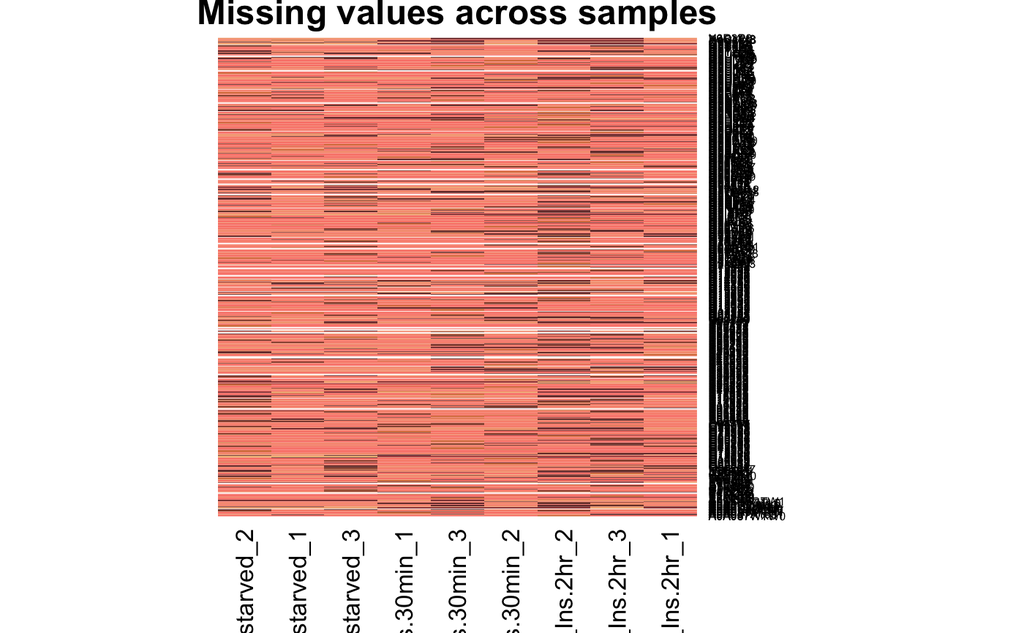

```r
#---------------------------------------------------------------------------------------------------------------------
# Filt 1 : Adding a filtering step to remove all proteins which are missing all values in each experimental condition
# This makes batch correction feasible using ComBat
#---------------------------------------------------------------------------------------------------------------------
missing.val = noimp[which(noimp$zero.starved == 3 | noimp$zero.30min == 3 | noimp$zero.2hr == 3),1:9] # 462 Uniprot ids
missing.val[is.na(missing.val)] = 0
# Plotting missing values
pal <- wes_palette(21, name = "GrandBudapest", type = "continuous")
heatmap(as.matrix(missing.val[,1:9]),na.rm=T,col=pal,Rowv=NA,Colv=NA, main = "Missing values across samples",cexRow = 0.6)
```

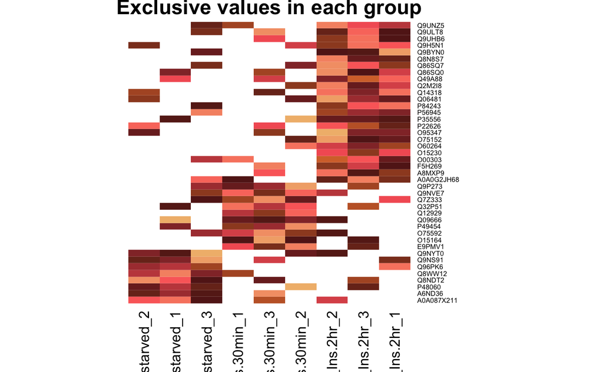

```r
#---------------------------------------------------------------------------------------------------
# Looking for those proteins that are exclusively present in the starved but absent from stimulated.
#---------------------------------------------------------------------------------------------------
# Looking for those proteins that are exclusively present in one group but not in the other two
exc.starved = noimp[which(noimp$zero.starved == 0 & noimp$zero.2hr > 1 & noimp$zero.30min > 1),]
exc.30min = noimp[which(noimp$zero.starved > 1 & noimp$zero.2hr > 1 & noimp$zero.30min == 0),]
exc.2hr = noimp[which(noimp$zero.starved > 1 & noimp$zero.2hr == 0 & noimp$zero.30min > 1),]
# Merge all exclusive proteins
excl = rbind(cbind(Condition = "Starved",exc.starved),cbind(Condition = "Ins.30min",exc.30min),cbind(Condition="2hr",exc.2hr))
heatmap(as.matrix(excl[,2:10],na.rm=T),col=pal,Rowv=NA,Colv=NA, main = "Exclusive values in each group",cexRow = 0.6)
```

```r
head(excl)
```

|  | Condition | A1_starved_2 | A2_starved_1 | A3_starved_3 | B1_Ins.30min_1 | B2_Ins.30min_3 | B3_Ins.30min_2 | C1_Ins.2hr_2 | C2_Ins.2hr_3 | C3_Ins.2hr_1 | zero.starved | zero.30min | zero.2hr | all |
| --- | --- | --- | --- | --- | --- | --- | --- | --- | --- | --- | --- | --- | --- | --- |
| A0A087X211 | Starved | 6.082116 | 6.056019 | 6.179661 | NA | 6.262823 | NA | 6.10196 | NA | NA | 0 | 2 | 2 | 4 |
| A6ND36 | Starved | 5.342149 | 5.237564 | 5.323659 | NA | 5.095698 | NA | NA | NA | NA | 0 | 2 | 3 | 5 |
| P48060 | Starved | 4.681472 | 4.653801 | 4.696915 | NA | NA | 4.594316 | NA | 4.701796 | NA | 0 | 2 | 2 | 4 |
| Q8NDT2 | Starved | 4.843817 | 4.870361 | 4.917774 | NA | 4.916749 | NA | NA | 4.957438 | NA | 0 | 2 | 2 | 4 |
| Q8WW12 | Starved | 5.614314 | 5.578886 | 5.627985 | 5.66476 | NA | NA | NA | NA | NA | 0 | 2 | 3 | 5 |
| Q96PK6 | Starved | 6.484762 | 6.481639 | 6.528411 | NA | NA | NA | NA | NA | 6.45423 | 0 | 3 | 2 | 5 |

```r
excl = as.data.frame(excl)
excl$ID = rownames(excl)
uni = fData(qnt.prot.no.imp)[which(fData(qnt.prot.no.imp)$Master.Protein.Accession %in% excl$ID),c("Master.Protein.Accessions","uniprot")]
excl.uni = merge(excl,uni,by.x="ID",by.y="Master.Protein.Accessions",all.x=T,all.y=F)
# Annotate this list
ann = data.frame(queryMany(rownames(excl),scopes="uniprot",fields=c("ensembl.gene","uniprot.Swiss-Prot","entrezgene","symbol","go.MF.term","go.CC.term","go.BP.term","interpro.desc"),species=9606))
```

```
Finished
Pass returnall=TRUE to return lists of duplicate or missing query terms.
```

```r
# Modify some annotations
for(j in c("ensembl","interpro","go.BP","go.CC","go.MF")){
  name = paste(j,"mod",sep=".")
  ann[,name] = sapply(ann[,j],function(x) paste(unlist(x),collapse="; "))
}
# Merge it with original data
excl.ann = merge(ann,excl.uni,by.x="query",by.y = "ID",all=T)
# Trim down data frame and add extra annotations to make it compatible with the RBP capture data
final.excl = excl.ann[order(excl.ann$Condition,excl.ann$symbol),c(17,7,1,11,5,12,18:31,13:16)]
rownames(final.excl) = final.excl$symbol
heatmap(as.matrix(final.excl[,7:15],na.rm=T),col=pal,Rowv=NA,Colv=NA, main = "Exclusive values in each group",cexRow = 0.8)
exc.melt = melt(final.excl[,c(2,7:15)],id = "symbol")
colnames(exc.melt) = c("Gene","Condition","Exp")
exc.melt$Exp = as.numeric(exc.melt$Exp)
exc.melt$Group = sapply(strsplit(as.character(exc.melt$Condition),"_"),"[[",2)
exc.g = ggplot(data=transform(exc.melt,Gene=factor(Gene,levels=exc.melt$Gene)),aes(x=Condition, y=Exp, group = Gene,color = Group)) + geom_line() + theme(axis.text.x=element_text(angle=90, hjust=1),legend.position="none",plot.title = element_text(hjust = 0.5))+facet_wrap(~Gene,scales="free_y")+labs(title="Expression of proteins exclusive to each condition")
```

```
duplicated levels in factors are deprecated
```

```r
pdf(paste(outdir,paste(format(Sys.time(),"%Y-%m-%d_%H.%M.%S"),suf,"Expression-in-exclusive-genes-in-whole-proteome.pdf",sep="_"),sep="/"),paper="a4r",width=12,height=8)
```

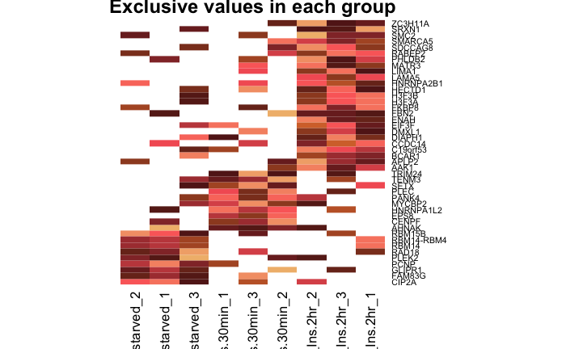

```r
print(exc.g)
dev.off()
```

```r
# Try and use clustercompare to look for functional themes
univ = fData(qnt.prot.no.imp)$Master.Protein.Accessions
univ.ann = myProtMapper(univ)
```

```
Querying chunk 1
Querying chunk 2
Querying chunk 3
Querying chunk 4
Querying chunk 5
Querying chunk 6
```

```
Finished
Pass returnall=TRUE to return lists of duplicate or missing query terms.
```

```
the condition has length > 1 and only the first element will be used
```

```r
# Make mapping for goseq analysis
univ.cat.go = makeGene2Cat(univ.ann,"query","go.all",";")
univ.cat.doms = makeGene2Cat(univ.ann,"query","domains",";")
# Adding more annotations
goterms <- Term(GOTERM)
ont<- Ontology(GOTERM)
md.go = compareCluster(query~Condition, data=final.excl,fun='enricher',universe = univ.ann$query,TERM2GENE = univ.cat.go[,c(2,1)],qvalueCutoff = 1)
md.go@compareClusterResult$Description = goterms[as.data.frame(md.go)$ID]
md.go@compareClusterResult$Ontology = ont[as.data.frame(md.go)$ID]
md.go.all = enricher(gene = final.excl$query, universe = univ.ann$query,TERM2GENE = univ.cat.go[,c(2,1)],qvalueCutoff = 1)
enricherPlot(md.go.all)
```

```
Error in `$<-.data.frame`(`*tmp*`, "tot.size", value = "\n()") :
  replacement has 1 row, data has 0
```

```r
#------------------------------------------------------------------------------------------------------------------------
# Step 07: Adding in data from Synapt based, label-free mass spectrometry data from Leicester
#------------------------------------------------------------------------------------------------------------------------
data.sum = NULL
all.data = NULL
sink(paste(outdir,"Stats-for-input-files.txt",sep="/"))
for (f in c("DDA_SCAFFOLD.txt","DIA_SCAFFOLD.txt","DIA_ISOQUANT.txt","DDA_PEAKS.txt")){
  dat = read.table(paste(indir,f,sep="/"),sep="\t",header=T,stringsAsFactors = F)
  print(f)
  print(dim(dat))
  s = apply(dat[,2:13],2,summary)
  print(s)
  print(summary(rowSums(is.na(dat[,2:13]))))
  d = data.frame(cbind(Source = rep(f,ncol(dat)-1), Samples = colnames(dat)[2:13],Total = as.numeric(nrow(dat)),Missing = as.numeric(s["NA's",])))
  data.sum = rbind(data.sum,d)
  all.data = rbind(all.data,cbind(Source = gsub(".txt","",f),dat))
}
sink()
# Some modifications
all.data$Source = as.character(all.data$Source)
all.data$Acquisition = sapply(strsplit(all.data$Source,"_"),"[[",1)
all.data$Caller = sapply(strsplit(all.data$Source,"_"),"[[",2)
mega = all.data[,c(2,15:16,1,3:14)]
head(data.sum)
```

|  | Source | Samples | Total | Missing |
| --- | --- | --- | --- | --- |
| 1 | DDA_SCAFFOLD.txt | NCL.A | 290 | 262 |
| 2 | DDA_SCAFFOLD.txt | NCL.B | 290 | 262 |
| 3 | DDA_SCAFFOLD.txt | NCL.C | 290 | 264 |
| 4 | DDA_SCAFFOLD.txt | U.A | 290 | 62 |
| 5 | DDA_SCAFFOLD.txt | U.B | 290 | 60 |
| 6 | DDA_SCAFFOLD.txt | U.C | 290 | 64 |

```r
head(mega)
```

|  | Accession | Acquisition | Caller | Source | NCL.A | NCL.B | NCL.C | U.A | U.B | U.C | S.A | S.B | S.C | IT.A | IT.B | IT.C |
| --- | --- | --- | --- | --- | --- | --- | --- | --- | --- | --- | --- | --- | --- | --- | --- | --- |
| 1 | ADH1_YEAST | DDA | SCAFFOLD | DDA_SCAFFOLD | 467 | 431 | 338 | 386 | 328 | 305 | 369 | 302 | 280 | 196 | 223 | 221 |
| 2 | NUCL_HUMAN | DDA | SCAFFOLD | DDA_SCAFFOLD | NA | NA | NA | 375 | 362 | 331 | 282 | 267 | 266 | 583 | 637 | 588 |
| 3 | ALBU_BOVIN | DDA | SCAFFOLD | DDA_SCAFFOLD | 339 | 298 | 215 | 259 | 236 | 202 | 259 | 237 | 210 | 148 | 160 | 163 |
| 4 | K2C1_HUMAN | DDA | SCAFFOLD | DDA_SCAFFOLD | 157 | 143 | 126 | 138 | 117 | 127 | 103 | 96 | 88 | 121 | 145 | 127 |
| 5 | RRP5_HUMAN | DDA | SCAFFOLD | DDA_SCAFFOLD | 17 | 24 | 9 | 117 | 114 | 80 | 110 | 115 | 99 | 182 | 193 | 187 |
| 6 | TRYP_PIG | DDA | SCAFFOLD | DDA_SCAFFOLD | 85 | 68 | 48 | 120 | 86 | 87 | 99 | 88 | 63 | 60 | 67 | 52 |

```r
# Number of RBPS
data.sum$Total = as.numeric(as.character(data.sum$Total))
data.sum$Missing = as.numeric(as.character(data.sum$Missing))
data.sum$RBPs = data.sum$Total-data.sum$Missing
str(data.sum)
```

```
'data.frame':   48 obs. of  5 variables:
 $ Source : Factor w/ 4 levels "DDA_SCAFFOLD.txt",..: 1 1 1 1 1 1 1 1 1 1 ...
 $ Samples: Factor w/ 12 levels "IT.A","IT.B",..: 4 5 6 10 11 12 7 8 9 1 ...
 $ Total  : num  290 290 290 290 290 290 290 290 290 290 ...
 $ Missing: num  262 262 264 62 60 64 87 82 91 23 ...
 $ RBPs   : num  28 28 26 228 230 226 203 208 199 267 ...
```

```r
# Melting the data for a barplot
ds.melt = melt(data.sum, id=c("Source", "Samples","Total"))
ds.melt <- within(ds.melt, Samples <- factor(Samples, levels=c("NCL.A","NCL.B","NCL.C","U.A","U.B","U.C","S.A","S.B","S.C","IT.A","IT.B","IT.C")))
# Drawing a barplot of the relative proportions of Missing and RBPs using DIA and DDA with various callers
# Missing means "NA" so no abundance values and no peptides for the protein.
pdf(paste(outdir,paste(format(Sys.time(),"%Y-%m-%d_%H.%M.%S"),"Barplot-showing-proportion-of-RBPs-across-conditions-callers.pdf",sep="_"),sep="/"),paper="a4r",width=12,height=8)
p <-ggplot(ds.melt, aes(Samples, value)) + geom_bar(stat = "identity", aes(fill = variable))+facet_wrap(~Source,scales="free")+labs(fill = "Number.of.proteins")+theme_bw()+
scale_fill_manual("legend", values = c("Missing" = "#541F12", "RBPs" = "#CC8B3C"))
print(p)
dev.off()
```

Each caller calls a different number of proteins - PEAKS calls the masimum number ~ 3800 while ISOQUANT is most conservative at ~ 220. Except for PEAKS, across all other callers, the trend is 1. High number of missing values/NA calls in the non-crosslinked samples (or) very few RBPS (woo hoo!) 2. Very low number of missing values/NA calls in crosslinked, Insulin stimulated (IT.A,IT.B,IT.C) samples (or) large number of RBPs 3. A trend showing a drop in the number of RBPs recovered going from Unstarved cells (U.A,U.B,U.C) to Starved cells (S.A,S.B,S.C)

These are numbers based on raw data but the data warrants a lot of filtering as we have several missing values and low spectral counts.

```r
#==================================================================================
# 07b : Filtering RBPs in the data set for most promising candidates
#==================================================================================
# Start with mega that has all RBP data for all callers and acquisition modes
# DIA is less specific but more sensitive. DDA is more specific but less sensitive. Therefore, more calls from DIA but also more dross. Fewer, reliable calls from DDA
head(mega)
```

|  | Accession | Acquisition | Caller | Source | NCL.A | NCL.B | NCL.C | U.A | U.B | U.C | S.A | S.B | S.C | IT.A | IT.B | IT.C |
| --- | --- | --- | --- | --- | --- | --- | --- | --- | --- | --- | --- | --- | --- | --- | --- | --- |
| 1 | ADH1_YEAST | DDA | SCAFFOLD | DDA_SCAFFOLD | 467 | 431 | 338 | 386 | 328 | 305 | 369 | 302 | 280 | 196 | 223 | 221 |
| 2 | NUCL_HUMAN | DDA | SCAFFOLD | DDA_SCAFFOLD | NA | NA | NA | 375 | 362 | 331 | 282 | 267 | 266 | 583 | 637 | 588 |
| 3 | ALBU_BOVIN | DDA | SCAFFOLD | DDA_SCAFFOLD | 339 | 298 | 215 | 259 | 236 | 202 | 259 | 237 | 210 | 148 | 160 | 163 |
| 4 | K2C1_HUMAN | DDA | SCAFFOLD | DDA_SCAFFOLD | 157 | 143 | 126 | 138 | 117 | 127 | 103 | 96 | 88 | 121 | 145 | 127 |
| 5 | RRP5_HUMAN | DDA | SCAFFOLD | DDA_SCAFFOLD | 17 | 24 | 9 | 117 | 114 | 80 | 110 | 115 | 99 | 182 | 193 | 187 |
| 6 | TRYP_PIG | DDA | SCAFFOLD | DDA_SCAFFOLD | 85 | 68 | 48 | 120 | 86 | 87 | 99 | 88 | 63 | 60 | 67 | 52 |

```r
dim(mega)
```

```
[1] 4766   16
```

```r
mega$nas = rowSums(is.na(mega[,5:16]))
table(mega$nas,mega$Source)
```

```
     DDA_PEAKS DDA_SCAFFOLD DIA_ISOQUANT DIA_SCAFFOLD
  0         48           21            7            7
  1         26            3            0            0
  2         40            4            0            4
  3        185          132           42           34
  4        102           19            0           27
  5        120           18            0           16
  6        127           17           37           26
  7        173           22            1           35
  8        245           23            0           53
  9        406           22          137           76
  10       664            7            0           79
  11      1701            2            0           58
```

```r
dim(mega) # 4766 proteins
```

```
[1] 4766   17
```

```r
#----------------------------------------------------------------------------------------------------------------------------------
# Filt 1 : First filter is to remove any proteins who are missing more than 9 values out of 12. This excludes genes where not even a single experimental conditions has a complete set of abundance calls.
#----------------------------------------------------------------------------------------------------------------------------------
filt.1 = mega[which(mega$nas <= 9),]
table(filt.1$nas,filt.1$Source)
```

```
    DDA_PEAKS DDA_SCAFFOLD DIA_ISOQUANT DIA_SCAFFOLD
  0        48           21            7            7
  1        26            3            0            0
  2        40            4            0            4
  3       185          132           42           34
  4       102           19            0           27
  5       120           18            0           16
  6       127           17           37           26
  7       173           22            1           35
  8       245           23            0           53
  9       406           22          137           76
```

```r
dim(filt.1) # 2255 proteins
```

```
[1] 2255   17
```

```r
#----------------------------------------------------------------------------------------------------------------------------------
# Filt 2 : Then remove common mass spec contaminants and spikeins - keratins, bovine albumin based on CCP list of contaminants
#----------------------------------------------------------------------------------------------------------------------------------
contam = read.table("Input/contam.txt",sep="\t",header=F,stringsAsFactors = F)
filt.2 = filt.1[-which(filt.1$Accession %in% contam$V1),]
table(filt.2$nas,filt.2$Caller)
```

```
    ISOQUANT PEAKS SCAFFOLD
  0        0    40       13
  1        0    26        3
  2        0    40        8
  3       42   184      166
  4        0   101       46
  5        0   120       34
  6       37   125       42
  7        1   173       56
  8        0   245       76
  9      136   403       97
```

```r
dim(filt.2) # 2214 proteins
```

```
[1] 2214   17
```

```r
#----------------------------------------------------------------------------------------------------------------------------------
# Filt 3 : Replace missing values with 0. Ading a column called "zeroes" so I can tell how many were 0 and how many were NAs
# This is not really a filter but I need to do this to be able to draw a PCA
#----------------------------------------------------------------------------------------------------------------------------------
filt.3 = filt.2
filt.3$zeroes = rowSums(filt.3 == 0)
filt.3[is.na(filt.3)] = 0
#----------------------------------------------------------------------------------------------------------------------------------
# Filt 4: Filtering for low expressors. Only keep those genes where the spectral count is greater than 2 in 3 or more samples
# This ensures that at least one condition has a complete set of abundances (on average)
#----------------------------------------------------------------------------------------------------------------------------------
keep.exprs <- rowSums(filt.3[,5:16]>3)>=3
filt.4 <- filt.3[keep.exprs,]
#----------------------------------------------------------------------------------------------------------------------------------
# Draw density plots showing the pre- and post- filtering distributions of gene expression by sample
#----------------------------------------------------------------------------------------------------------------------------------
# Set up colours
nsamples <- 12
coul <- brewer.pal(12, "Paired")
col = colorRampPalette(coul)(nsamples)
# Histogram showing removal of low expressing genes
pdf(paste(outdir,paste(format(Sys.time(),"%Y-%m-%d_%H.%M.%S"),"Density-plots-of-protein-abundance.pdf",sep="_"),sep="/"),paper="a4r",width=12,height=8)
par(mfrow=c(1,2))
# Pre-filtered data (filt.3)
plot(density(filt.3[,5]), col=col[1], lwd=2, ylim=c(0,1),xaxp=c(0,50,25), las=2, main="", xlab="")
title(main=paste("A. Raw data (n = 0, ",nrow(filt.3)," proteins)", sep=""), xlab="Spectral count")
abline(v=0, lty=3)
for (i in 6:16){
  den <- density(filt.3[,i])
  lines(den$x, den$y, col=col[i], lwd=2)
}
legend("topright",colnames(filt.3)[5:16], text.col=col, bty="n",cex=1)
# Post-filtering data (filt.4)
plot(density(filt.4[,5]), col=col[1], lwd=2, ylim=c(0,1),xaxp=c(0,50,25), las=2, main="", xlab="")
```

```r
title(main=paste("B. Filtered data (n = 3, ",nrow(filt.4)," proteins)", sep=""), xlab="Spectral count")
abline(v=0, lty=3)
for (i in 6:16){
  den <- density(filt.4[,i])
  lines(den$x, den$y, col=col[i], lwd=2)
}
legend("topright",colnames(filt.4)[5:16], text.col=col, bty="n",cex=1)
dev.off()
```

```r
# Some basic stats on the data before we move on
table(mega$Source)
```

```
   DDA_PEAKS DDA_SCAFFOLD DIA_ISOQUANT DIA_SCAFFOLD
        3837          290          224          415
```

```r
table(filt.1$Source)
```

```
   DDA_PEAKS DDA_SCAFFOLD DIA_ISOQUANT DIA_SCAFFOLD
        1472          281          224          278
```

```r
table(filt.2$Source)
```

```
   DDA_PEAKS DDA_SCAFFOLD DIA_ISOQUANT DIA_SCAFFOLD
        1457          272          216          269
```

```r
table(filt.3$Source)
```

```
   DDA_PEAKS DDA_SCAFFOLD DIA_ISOQUANT DIA_SCAFFOLD
        1457          272          216          269
```

```r
table(filt.4$Source)
```

```
   DDA_PEAKS DDA_SCAFFOLD DIA_ISOQUANT DIA_SCAFFOLD
         415          212          212          140
```

We have put the data through 4 steps of filtering - removing rows with mostly NAs, removing contaminants, replacing NAs with 0 and finally, remove genes that are lowly expressed in multiple samples. We now have a set of 979 proteins across the 4 caller/sources which we’d like to investigate further.

```r
#==================================================================================
# 07c : Taking a closer look at filtered data
#==================================================================================
head(filt.4)
```

|  | Accession | Acquisition | Caller | Source | NCL.A | NCL.B | NCL.C | U.A | U.B | U.C | S.A | S.B | S.C | IT.A | IT.B | IT.C | nas | zeroes |
| --- | --- | --- | --- | --- | --- | --- | --- | --- | --- | --- | --- | --- | --- | --- | --- | --- | --- | --- |
| 2 | NUCL_HUMAN | DDA | SCAFFOLD | DDA_SCAFFOLD | 0 | 0 | 0 | 375 | 362 | 331 | 282 | 267 | 266 | 583 | 637 | 588 | 3 | 0 |
| 5 | RRP5_HUMAN | DDA | SCAFFOLD | DDA_SCAFFOLD | 17 | 24 | 9 | 117 | 114 | 80 | 110 | 115 | 99 | 182 | 193 | 187 | 0 | 1 |
| 7 | LPPRC_HUMAN | DDA | SCAFFOLD | DDA_SCAFFOLD | 0 | 0 | 0 | 95 | 70 | 73 | 94 | 97 | 88 | 151 | 129 | 128 | 3 | 0 |
| 8 | DDX21_HUMAN | DDA | SCAFFOLD | DDA_SCAFFOLD | 0 | 0 | 0 | 104 | 88 | 80 | 97 | 83 | 94 | 129 | 155 | 139 | 3 | 0 |
| 10 | HNRPQ_HUMAN | DDA | SCAFFOLD | DDA_SCAFFOLD | 0 | 0 | 0 | 96 | 87 | 74 | 80 | 88 | 63 | 108 | 125 | 103 | 3 | 0 |
| 11 | RL1D1_HUMAN | DDA | SCAFFOLD | DDA_SCAFFOLD | 0 | 0 | 0 | 77 | 78 | 71 | 61 | 69 | 60 | 107 | 124 | 127 | 3 | 0 |

```r
dim(filt.4)
table(filt.4$Source)
# Splitting data by caller/source
# Normalising within each caller by mean of each sample (columnMeans) as each sample was a separate run of the mass spec
dia.scaf = filt.4[which(filt.4$Source == "DIA_SCAFFOLD"),]
#rownames(dia.scaf) = dia.scaf$Accession
dia.scaf[,5:16] = sweep(dia.scaf[,5:16],2,colMeans(dia.scaf[,5:16]),"/")
dda.scaf = filt.4[which(filt.4$Source == "DDA_SCAFFOLD"),]
#rownames(dda.scaf) = dda.scaf$Accession
dda.scaf[,5:16] = sweep(dda.scaf[,5:16],2,colMeans(dda.scaf[,5:16]),"/")
dda.peaks = filt.4[which(filt.4$Source == "DDA_PEAKS"),]
#rownames(dda.peaks) = dda.peaks$Accession
dda.peaks[,5:16] = sweep(dda.peaks[,5:16],2,colMeans(dda.peaks[,5:16]),"/")
dia.isoq = filt.4[which(filt.4$Source == "DIA_ISOQUANT"),]
#rownames(dia.isoq) = dia.isoq$Accession
dia.isoq[,5:16] = sweep(dia.isoq[,5:16],2,colMeans(dia.isoq[,5:16]),"/")
# Some stats and plots for each caller
pal = wes_palette("Darjeeling")
samples = rep(c("NCL","U","S","IT"),each=3)
names = c("DIA_SCAFFOLD","DDA_SCAFFOLD","DDA_PEAKS","DIA_ISOQUANT")
c = 1
#----------------------------------
# PCA for each caller
#----------------------------------
sink(paste(outdir,"Median-value-distribution-across-samples-callers.txt",sep="/"))
pdf(paste(outdir,paste(format(Sys.time(),"%Y-%m-%d_%H.%M.%S"),"PCA-plots-across-callers.pdf",sep="_"),sep="/"),paper="a4r",width=12,height=8)
for(m in list(dia.scaf,dda.scaf,dda.peaks,dia.isoq)){
  tmp = m[,5:16]
  print(names[c])
  print("Median value for each sample")
  print(apply(tmp,2,function(x) median(x,na.rm=TRUE)))
  print("Number of proteins below median value for each sample")
  print(apply(tmp,2,function(x) length(x[which(x < median(x,na.rm=TRUE))])))
  pca = prcomp(t(tmp))
  summary(pca)
  p <- ggbiplot(pca,choices=c(1,2), var.axes=F, groups = samples, circle = T,labels=rownames(pca$x),colour = pal[as.factor(samples)])+labs(title = paste("PCA plot for ", names[c],sep=""))+scale_colour_manual(name = "Condition",values=c("NCL" = "#00A08A","U" = "#F98400","S" = "#F2AD00","IT" = "#FF0000"))+ theme(plot.title = element_text(hjust = 0.5))
  print(p)

  c = c+1

  }
dev.off()
sink()
#----------------------------------
# Venn diagram comparing callers
#----------------------------------
v = gplots::venn(list(DDA_SCAFFOLD=unique(dda.scaf$Accession), DIA_SCAFFOLD = unique(dia.scaf$Accession), DDA_PEAKS = unique(dda.peaks$Accession), DIA_ISOQ = unique(dia.isoq$Accession)),show.plot = F)
venn.all = venn.diagram(list(unique(dda.scaf$Accession),unique(dia.scaf$Accession),unique(dda.peaks$Accession), unique(dia.isoq$Accession)), NULL, fill=c("#00A08A","#F98400","#F2AD00","#FF0000"), alpha=c(rep(0.5,4)), cex = 2, cat.cex=1.5, category.names = c("DDA_SCAFFOLD","DIA_SCAFFOLD","DDA_PEAKS","DIA_ISOQ"))
grid.draw(venn.all)
```

```r
# Draw venn diagram of protein overlap between callers after filtering
pdf(paste(outdir,paste(format(Sys.time(),"%Y-%m-%d_%H.%M.%S"),"Venn-diagram-across-callers-with-filtering.pdf",sep="_"),sep="/"),paper="a4r",width=12,height=8)
grid.draw(venn.all)
```

```r
dev.off()
#----------------------------------
# Draw heatmap of data by caller
# Can change to better colours
#----------------------------------
pdf(paste(outdir,paste(format(Sys.time(),"%Y-%m-%d_%H.%M.%S"),"Heatmaps-of-filtered-data-by-caller.pdf",sep="_"),sep="/"),paper="a4r",width=12,height=8)
```

```r
mypalette <- brewer.pal(11,"RdYlBu")
morecols <- colorRampPalette(mypalette)
heatmap.2(as.matrix(dia.scaf[,5:16]),col=rev(morecols(50)),trace="none",main="Expression of proteins called based on DIA using SCAFFOLD",scale="row",labRow = dia.scaf$Accession ,keysize=1,key.title = "",tracecol="black",cexRow = 0.3,dendrogram="column")
heatmap.2(as.matrix(dda.scaf[,5:16]),col=rev(morecols(50)),trace="none",main="Expression of proteins called based on DDA using SCAFFOLD",scale="row",labRow = dda.scaf$Accession ,keysize=1,key.title = "",tracecol="black",cexRow = 0.3,dendrogram="column")
```

```r
heatmap.2(as.matrix(dda.peaks[,5:16]),col=rev(morecols(50)),trace="none",main="Expression of proteins called based on DDA using PEAKS",scale="row",labRow = dda.peaks$Accession ,keysize=1,key.title = "",tracecol="black",cexRow = 0.3,dendrogram="column")
heatmap.2(as.matrix(dia.isoq[,5:16]),col=rev(morecols(50)),trace="none",main="Expression of proteins called based on DIA using ISOQUANT",scale="row",labRow = dia.isoq$Accession ,keysize=1,key.title = "",tracecol="black",cexRow = 0.3,dendrogram="column")
```

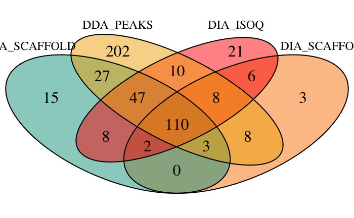

```r
dev.off()
```

```r
#-------------------------------------------------------------------------------------------------------------------------------------
# Pulling out proteins common to all callers to look at their trend in protein expression (based on venn diagram 'v')
#-------------------------------------------------------------------------------------------------------------------------------------
common.prots = filt.4[which(filt.4$Accession %in% attr(v,"intersections")$`DDA_SCAFFOLD:DIA_SCAFFOLD:DDA_PEAKS:DIA_ISOQ`),]
common.prots = common.prots[order(common.prots$Accession),]
norm.comm = rbind(dia.scaf,dda.scaf,dda.peaks)
dim(norm.comm)
norm.comm = norm.comm[which(norm.comm$Accession %in% unique(common.prots$Accession)),]
dim(norm.comm)
# Melt the dataframe for ggplot compatibility
com.melt = melt(norm.comm,id = c("Accession","Acquisition","Caller","Source","nas","zeroes"))
colnames(com.melt)[7:8] = c("Condition","Exp")
com.melt$Exp = as.numeric(com.melt$Exp)
com.melt$Tmt = sapply(strsplit(as.character(com.melt$Condition),"\\."),"[[",1)
com.melt$Tmt = factor(com.melt$Tmt,levels = c('NCL','U','S','IT'),ordered = TRUE)
# Regression
t = unstack(com.melt,Exp~Source)
cor(t)
ggcorr(t,palette = "RdGy",label=T,label_round=3,label_size=6)
# Excludes Isoquant as this is the only absolute quantification and units are in fmol. Rest are spectral counts
pdf(paste(outdir,paste(format(Sys.time(),"%Y-%m-%d_%H.%M.%S"),"Filtered-common-genes-across-callers-violinplot_NO-ISOQUANT.pdf",sep="_"),sep="/"),paper="a4r",width=12,height=8)
```

```r
gg2 = ggplot(data=com.melt[which(com.melt$Source != "DIA_ISOQUANT"),],aes(x=Tmt, y=Exp, group = Tmt,fill=Tmt)) + geom_violin() +stat_summary(aes(group=1),fun.y=median, geom="line", color="black", size=0.5,lty = 2) + theme(legend.position="top")+labs(fill = "Treatment")+ scale_fill_manual(values=c("#E2D200","#46ACC8","#E58601","#B40F20"))+facet_wrap(~Accession)
gg10 <- facet_multiple(plot=gg2, facets="Accession", ncol = 4, nrow = 4, scales = "free_y")
dev.off()
```

```r
# Reading in mapped IDs from uniprot
upcom = read.delim("Files-to-send/RBP-capture-common-prots-id-mapping.tab",sep="\t",header=T)
rownames(upcom) = upcom$Entry
comprots.ann = merge(common.prots,upcom, by.x = "Accession", by.y = "Entry.name",all.x=T)
# Attempting to cluster the genes
clusdat = norm.comm[,5:16]
rownames(clusdat) = paste(norm.comm$Accession,norm.comm$Source,sep=".")
# Drawing a heatmap of most common genes
col.cell <- pal[as.factor(samples)]
pal2 <- c("#7496D2","#E6A2C5","#CECD7B")
row.cell = pal2[as.numeric(as.factor(sapply(strsplit(rownames(clusdat),"\\."),"[[",2)))]
row.labs = gsub("_HUMAN|DIA|DDA|\\.|SCAFFOLD|PEAKS|ISOQUANT|\\_","",rownames(clusdat))
# Plot the heatmap
pdf(paste(outdir,paste(format(Sys.time(),"%Y-%m-%d_%H.%M.%S"),"Filtered-common-genes-across_HEATMAP.pdf",sep="_"),sep="/"),paper="a4r",width=12,height=8)
hm = heatmap.2(as.matrix(clusdat),col=rev(morecols(50)),trace="none",main="Heatmap of 110 common proteins",ColSideColors=col.cell,RowSideColors = row.cell,scale="row",labRow = row.labs ,keysize=1,key.title = "",tracecol="black",cexRow = 0.2,dendrogram="column")
```

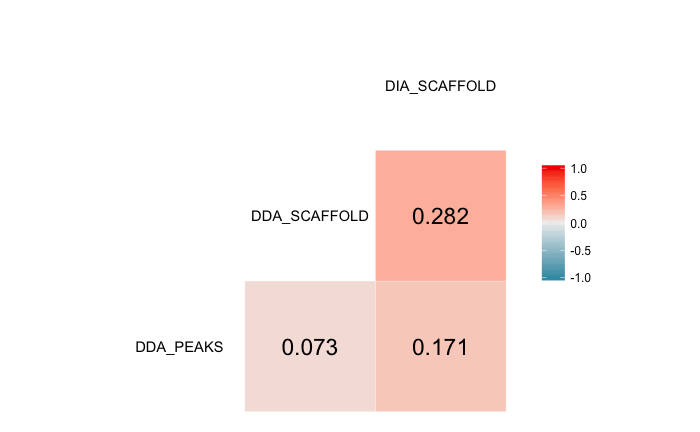

```r
dev.off()
```

```r
#---------------------------------------------------------------------------------------------------------------
# Functional enrichment of 110 proteins using whole proteome as background
#---------------------------------------------------------------------------------------------------------------
# Reading in whole proteome ids form uniprot to obtain protein length to provide as bias to goseq
mcf10prot = read.delim("Files-to-send/Whole-proteome-all-id-mapping.tab",sep="\t",header=T)
dim(mcf10prot)
```

```
[1] 5919   12
```

```r
# Checking the overlap with whole proteome. Of 110 proteins, 100 occur in the whole proteome
# 10 missing ones are listed below.
# It seems as if MATR3 is misisng from the whole proteome but it just is under a different Uniprot ID which is "A8MXP9" instead of P43243
miss.wholprot = setdiff(upcom$Entry,fData(qnt.prot.no.imp)$Master.Protein.Accessions)
upcom[intersect(upcom$Entry,miss.wholprot),]
```

|  | Entry | Entry.name | Status | Protein.names | Gene.names | Organism | Cross.reference..InterPro. | Gene.ontology..biological.process. | Gene.ontology..cellular.component. | Gene.ontology..molecular.function. | Length |
| --- | --- | --- | --- | --- | --- | --- | --- | --- | --- | --- | --- |
| O00571 | O00571 | DDX3X_HUMAN | reviewed | ATP-dependent RNA helicase DDX3X (EC 3.6.4.13) (DEAD box protein 3, X-chromosomal) (DEAD box, X isoform) (Helicase-like protein 2) (HLP2) | DDX3X DBX DDX3 | Homo sapiens (Human) | IPR011545;IPR014001;IPR001650;IPR027417;IPR000629;IPR014014; | cellular response to arsenic-containing substance [GO:0071243]; cellular response to osmotic stress [GO:0071470]; chromosome segregation [GO:0007059]; extrinsic apoptotic signaling pathway via death d… | cytoplasm [GO:0005737]; cytoplasmic stress granule [GO:0010494]; cytosol [GO:0005829]; extracellular exosome [GO:0070062]; extracellular region [GO:0005576]; ficolin-1-rich granule lumen [GO:1904813];… | ATPase activity [GO:0016887]; ATP binding [GO:0005524]; ATP-dependent DNA helicase activity [GO:0004003]; ATP-dependent RNA helicase activity [GO:0004004]; cadherin binding [GO:0045296]; CTPase activi… | 662 |
| P17844 | P17844 | DDX5_HUMAN | reviewed | Probable ATP-dependent RNA helicase DDX5 (EC 3.6.4.13) (DEAD box protein 5) (RNA helicase p68) | DDX5 G17P1 HELR HLR1 | Homo sapiens (Human) | IPR033488;IPR011545;IPR014001;IPR001650;IPR027417;IPR012587;IPR000629;IPR014014; | alternative mRNA splicing, via spliceosome [GO:0000380]; androgen receptor signaling pathway [GO:0030521]; BMP signaling pathway [GO:0030509]; cell growth [GO:0016049]; epithelial to mesenchymal trans… | catalytic step 2 spliceosome [GO:0071013]; cytoplasm [GO:0005737]; extracellular exosome [GO:0070062]; extracellular matrix [GO:0031012]; intracellular ribonucleoprotein complex [GO:0030529]; membrane… | androgen receptor binding [GO:0050681]; ATP binding [GO:0005524]; ATP-dependent RNA helicase activity [GO:0004004]; calcium-dependent protein binding [GO:0048306]; calmodulin binding [GO:0005516]; enz… | 614 |
| Q9NP87 | Q9NP87 | DPOLM_HUMAN | reviewed | DNA-directed DNA/RNA polymerase mu (Pol Mu) (EC 2.7.7.7) (Terminal transferase) | POLM polmu | Homo sapiens (Human) | IPR001357;IPR036420;IPR002054;IPR027249;IPR019843;IPR010996;IPR028207;IPR018944;IPR027421;IPR037160;IPR022312;IPR029398;IPR001726; | B cell differentiation [GO:0030183]; DNA recombination [GO:0006310]; double-strand break repair via nonhomologous end joining [GO:0006303]; somatic hypermutation of immunoglobulin genes [GO:0016446] | nucleoplasm [GO:0005654] | DNA binding [GO:0003677]; DNA-directed DNA polymerase activity [GO:0003887]; metal ion binding [GO:0046872] | 494 |
| Q12926 | Q12926 | ELAV2_HUMAN | reviewed | ELAV-like protein 2 (ELAV-like neuronal protein 1) (Hu-antigen B) (HuB) (Nervous system-specific RNA-binding protein Hel-N1) | ELAVL2 HUB | Homo sapiens (Human) | IPR006548;IPR034775;IPR034999;IPR034914;IPR002343;IPR035979;IPR000504; | mRNA splicing, via spliceosome [GO:0000398]; regulation of transcription, DNA-templated [GO:0006355] | nucleoplasm [GO:0005654] | mRNA 3'-UTR binding [GO:0003730]; RNA binding [GO:0003723] | 359 |
| P31943 | P31943 | HNRH1_HUMAN | reviewed | Heterogeneous nuclear ribonucleoprotein H (hnRNP H) [Cleaved into: Heterogeneous nuclear ribonucleoprotein H, N-terminally processed] | HNRNPH1 HNRPH HNRPH1 | Homo sapiens (Human) | IPR035979;IPR000504;IPR012996; | fibroblast growth factor receptor signaling pathway [GO:0008543]; mRNA splicing, via spliceosome [GO:0000398]; regulation of RNA splicing [GO:0043484]; RNA metabolic process [GO:0016070]; RNA processi… | catalytic step 2 spliceosome [GO:0071013]; cytosol [GO:0005829]; membrane [GO:0016020]; nucleoplasm [GO:0005654]; nucleus [GO:0005634] | poly(U) RNA binding [GO:0008266]; RNA binding [GO:0003723] | 449 |
| P23588 | P23588 | IF4B_HUMAN | reviewed | Eukaryotic translation initiation factor 4B (eIF-4B) | EIF4B | Homo sapiens (Human) | IPR033107;IPR035979;IPR000504; | eukaryotic translation initiation factor 4F complex assembly [GO:0097010]; formation of translation preinitiation complex [GO:0001731]; nuclear-transcribed mRNA poly(A) tail shortening [GO:0000289]; r… | cytosol [GO:0005829]; eukaryotic translation initiation factor 4F complex [GO:0016281]; polysome [GO:0005844] | helicase activity [GO:0004386]; ribosomal small subunit binding [GO:0043024]; RNA binding [GO:0003723]; RNA strand annealing activity [GO:0033592]; RNA strand-exchange activity [GO:0034057]; translati… | 611 |
| P43243 | P43243 | MATR3_HUMAN | reviewed | Matrin-3 | MATR3 KIAA0723 | Homo sapiens (Human) | IPR034928;IPR034930;IPR000690;IPR003604;IPR035979;IPR000504; | activation of innate immune response [GO:0002218]; innate immune response [GO:0045087]; posttranscriptional regulation of gene expression [GO:0010608] | membrane [GO:0016020]; nuclear inner membrane [GO:0005637]; nuclear matrix [GO:0016363] | identical protein binding [GO:0042802]; miRNA binding [GO:0035198]; RNA binding [GO:0003723]; structural molecule activity [GO:0005198]; zinc ion binding [GO:0008270] | 847 |
| Q6P5R6 | Q6P5R6 | RL22L_HUMAN | reviewed | 60S ribosomal protein L22-like 1 (Large ribosomal subunit protein eL22-like 1) | RPL22L1 | Homo sapiens (Human) | IPR002671;IPR028370; | cytoplasmic translation [GO:0002181] | cytosolic large ribosomal subunit [GO:0022625] | RNA binding [GO:0003723]; structural constituent of ribosome [GO:0003735] | 122 |
| P62899 | P62899 | RL31_HUMAN | reviewed | 60S ribosomal protein L31 (Large ribosomal subunit protein eL31) | RPL31 | Homo sapiens (Human) | IPR000054;IPR020052;IPR023621; | cytoplasmic translation [GO:0002181]; nuclear-transcribed mRNA catabolic process, nonsense-mediated decay [GO:0000184]; rRNA processing [GO:0006364]; SRP-dependent cotranslational protein targeting to… | cytosol [GO:0005829]; cytosolic large ribosomal subunit [GO:0022625]; extracellular exosome [GO:0070062]; focal adhesion [GO:0005925]; membrane [GO:0016020] | RNA binding [GO:0003723]; structural constituent of ribosome [GO:0003735] | 125 |
| Q7Z2W4 | Q7Z2W4 | ZCCHV_HUMAN | reviewed | Zinc finger CCCH-type antiviral protein 1 (ADP-ribosyltransferase diphtheria toxin-like 13) (ARTD13) (Zinc finger CCCH domain-containing protein 2) (Zinc finger antiviral protein) (ZAP) | ZC3HAV1 ZC3HDC2 PRO1677 | Homo sapiens (Human) | IPR012317;IPR004170;IPR037197;IPR000571;IPR036855; | defense response to virus [GO:0051607]; innate immune response [GO:0045087]; negative regulation of viral genome replication [GO:0045071]; positive regulation of I-kappaB kinase/NF-kappaB signaling [G… | cytoplasm [GO:0005737]; cytosol [GO:0005829]; nucleus [GO:0005634] | cadherin binding [GO:0045296]; metal ion binding [GO:0046872]; RNA binding [GO:0003723] | 902 |

```r
ann[which(ann$uniprot.Swiss.Prot %in% miss.wholprot),]
```

|  | query | X_id | X_score | ensembl | entrezgene | interpro | symbol | go.BP | go.CC | go.MF | uniprot.Swiss.Prot | ensembl.mod | interpro.mod | go.BP.mod | go.CC.mod | go.MF.mod |
| --- | --- | --- | --- | --- | --- | --- | --- | --- | --- | --- | --- | --- | --- | --- | --- | --- |
| 21 | A8MXP9 | 9782 | 4.019916 |  | 9782 |  | MATR3 |  |  |  | P43243 | ENSG00000280987; ENSG00000015479 | RNA recognition motif domain; Matrin/U1-C, C2H2-type zinc finger; Matrin/U1-C-like, C2H2-type zinc finger | activation of innate immune response; posttranscriptional regulation of gene expression; innate immune response | nuclear inner membrane; membrane; nuclear matrix | RNA binding; structural molecule activity; protein binding; zinc ion binding; miRNA binding; identical protein binding |

```
all.genes
   0    1
5819  100
```

```
initial point very close to some inequality constraints
```

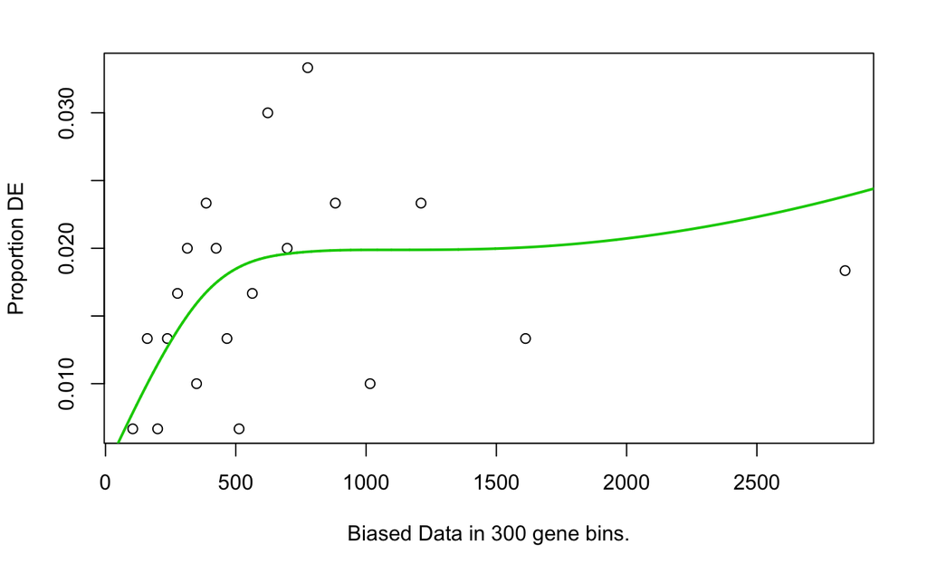

```r
go.110 = rungoseq(upcom$Entry,univ.cat.go,fData(qnt.prot.no.imp)$Master.Protein.Accessions)
```

```
all.genes
   0    1
5819  100
```

```
initial point very close to some inequality constraints
```

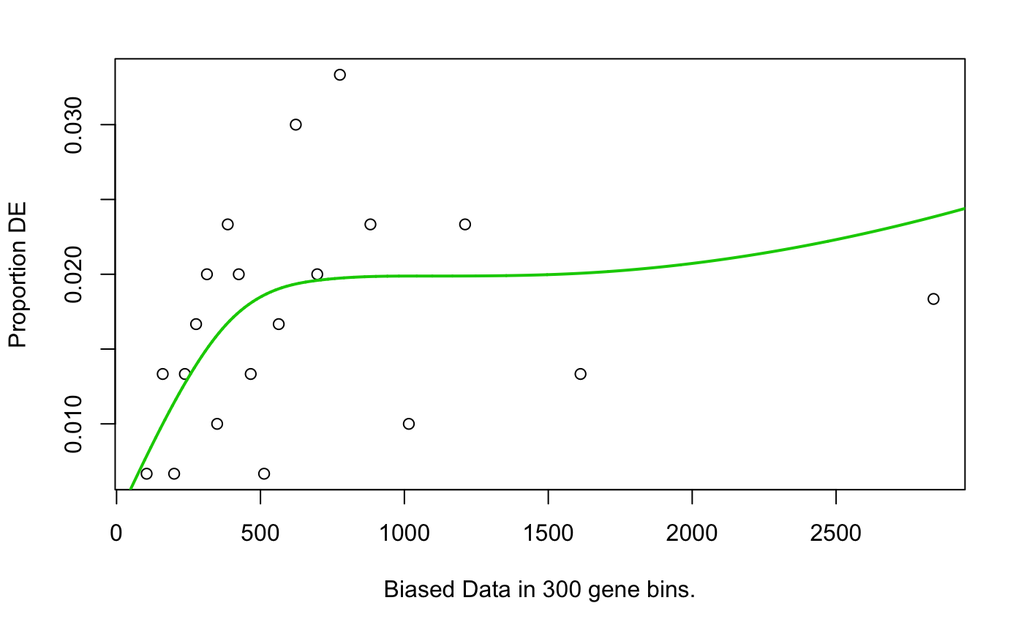

```r
pro.110 = rungoseq(upcom$Entry,univ.cat.doms,fData(qnt.prot.no.imp)$Master.Protein.Accessions)
```

```r
write.table(go.110[[2]][,c(1,6:8,4:5,9:10)],paste(outdir,"Common-proteins-GO-enrichment.txt",sep="/"),sep="\t",quote=F,row.names=F)
write.table(pro.110[[2]][,c(1,4:8)],paste(outdir,"Common-proteins-Interpro-enrichment.txt",sep="/"),sep="\t",quote=F,row.names=F)
```

```r
#---------------------------------------------------------------------------------------------------------------
# Comparing this list to Mark/David's list to see if this can be an orthogonal validation
#---------------------------------------------------------------------------------------------------------------
md = read.delim("Input/MarkDavid-RBPlist.txt",sep="\t",header=T)
md.vero = md[which(md$Uniprot.ID %in% unique(common.prots$Accession)),]
table(md.vero$RNAPI)
```

```
  dependent independent
         37          64
```

```r
# Merge md, comm.melt and groupings data
gp = read.table("Input/Common-110-by-group.txt",sep="\t",header=T)
gp.md = merge(gp,md,by.x="Protein",by.y = "Uniprot.ID")
gp.md.up = merge(gp.md,upcom[,1:2],by.x="Protein",by.y="Entry.name")
# Check for any difference in groupings
# There is a larger number of Group1 proteins in RNAPI.dep vs RNAPI.indep samples
y = as.data.frame.matrix(t(table(gp.md$RNAPI,gp.md$Group)))
y$Group = rownames(y)
y$prop.test.pval = round(sapply(1:nrow(y), function(z) prop.test(c(y[z,1],y[z,2]),c(37,64),correct=F, alternative="two.sided")$p.value),4)
```

```
Chi-squared approximation may be incorrectChi-squared approximation may be incorrectChi-squared approximation may be incorrect
```

```r
y$total.dep = 37
y$dep.prop = round(y$dependent/y$total.dep,2)
y$total.indep = 64
y$indep.prop = round(y$independent/y$total.indep,2)
y = y[,c(3,1,5,6,2,7,8,4)]
c = compareCluster(Entry~Group,data = gp.md.up,fun='enricher', universe = fData(qnt.prot.no.imp)$Master.Protein.Accessions,TERM2GENE = univ.cat.go[,c(2,1)],qvalueCutoff = 0.05)
c@compareClusterResult$Description = goterms[as.data.frame(c)$ID]
c@compareClusterResult$Ontology = ont[as.data.frame(c)$ID]
d = compareCluster(Entry~Group,data = gp.md.up,fun='enricher', universe = fData(qnt.prot.no.imp)$Master.Protein.Accessions,TERM2GENE = univ.cat.doms[,c(2,1)],qvalueCutoff = 0.05)
d.df = data.frame(d)
d.df$symbol = sapply(d.df$geneID, function(x) paste(bitr(unlist(strsplit(x,"/")),fromType="UNIPROT", toType=c("SYMBOL"), OrgDb=org.Hs.eg.db)$SYMBOL,collapse="/"))
ego = enricherPlot(data=c,N=5,suf="GO-Across-7-RBP-profile-groups",trunc.len=50,y.size=14,all.size=16)
epro = enricherPlot(data=d,N=5,suf="GO-Across-7-RBP-profile-groups",trunc.len=50,y.size=14,all.size=16)
c.df = data.frame(c)
c.df$symbol = sapply(c.df$geneID, function(x) paste(bitr(unlist(strsplit(x,"/")),fromType="UNIPROT", toType=c("SYMBOL"), OrgDb=org.Hs.eg.db)$SYMBOL,collapse="/"))
# Split into indep and dependent
md.vero.dep = as.character(md.vero$Uniprot.ID[which(md.vero$RNAPI == "dependent")])
md.vero.indep = as.character(md.vero$Uniprot.ID[which(md.vero$RNAPI == "independent")])
# Get the protein spectral counts
md.vero.dep.rbp = com.melt[which(com.melt$Accession %in% md.vero.dep),]
md.vero.indep.rbp = com.melt[which(com.melt$Accession %in% md.vero.indep),]
# Plot
pdf(paste(outdir,paste(format(Sys.time(),"%Y-%m-%d_%H.%M.%S"),"RNAPI-dependent-common-genes-across-callers-violinplot.pdf",sep="_"),sep="/"),paper="a4r",width=12,height=8)
gg2 = ggplot(data=md.vero.dep.rbp,aes(x=Tmt, y=Exp, group = Tmt,fill=Tmt)) + geom_violin() +stat_summary(aes(group=1),fun.y=median, geom="line", color="black", size=0.5,lty = 2) + theme(legend.position="top")+labs(fill = "Treatment")+ scale_fill_manual(values=c("#E2D200","#46ACC8","#E58601","#B40F20"))+facet_wrap(~Accession)
gg10 <- facet_multiple(plot=gg2, facets="Accession", ncol = 4, nrow = 4, scales = "free_y")
dev.off()
```

```r
pdf(paste(outdir,paste(format(Sys.time(),"%Y-%m-%d_%H.%M.%S"),"RNAPI-independent-common-genes-across-callers-violinplot.pdf",sep="_"),sep="/"),paper="a4r",width=12,height=8)
```

```r
gg2 = ggplot(data=md.vero.indep.rbp,aes(x=Tmt, y=Exp, group = Tmt,fill=Tmt)) + geom_violin() +stat_summary(aes(group=1),fun.y=median, geom="line", color="black", size=0.5,lty = 2) + theme(legend.position="top")+labs(fill = "Treatment")+ scale_fill_manual(values=c("#E2D200","#46ACC8","#E58601","#B40F20"))+facet_wrap(~Accession)
gg10 <- facet_multiple(plot=gg2, facets="Accession", ncol = 4, nrow = 4, scales = "free_y")
dev.off()
```

[figure not shown]

```r
#--------------------------------------------------------------------------------------------
# Function: rungoseq
# Aim:  goseq analysis
# Input : oops = genelist of interest; g2c = gene to category mapping i.e univ.go or univ.pro
#--------------------------------------------------------------------------------------------
rungoseq<-function(oops,g2c, univ){

  all.genes = rep(0,length(univ))
  names(all.genes) = univ
  all.genes[which(names(all.genes) %in% oops)] = 1
  print(table(all.genes))

  pwf = nullp(all.genes,bias.data = mcf10prot$Length,plot.fit = T)
  GO.wall = goseq(pwf,gene2cat = g2c)
  GO.wall$BH = p.adjust(GO.wall$over_represented_pvalue,method = "BH")
  head(GO.wall)

  GO.enriched = GO.wall[which(GO.wall$BH <= 0.1),]
  GO.enriched$geneID = sapply(GO.enriched$category,function(x) paste(intersect(oops,g2c$query[grep(x,g2c$to.id)]),collapse="/"))
  GO.enriched$Symbol = sapply(GO.enriched$geneID, function(x) paste(bitr(unlist(strsplit(x,"/")),fromType="UNIPROT", toType=c("SYMBOL"), OrgDb=org.Hs.eg.db)$SYMBOL,collapse="/"))

  return(list(GO.wall,GO.enriched))
}
```